# Analytes by site

# Setup

> Make matrix of site vs counts of observations of each analyte - including ALL SITES for now, not just our long term ones

```r
sisyn <- read_csv("20201111_masterdata_RAW.csv")

thematrix <- sisyn %>%
  select(LTER, site, variable, value) %>%
  count(LTER, site, variable, sort=TRUE) %>%
  pivot_wider(names_from = variable, values_from = n)%>%
  filter(!is.na(site)) #%>%
#  column_to_rownames(var="site")

thematrix[is.na(thematrix)] <- 0 #turns NAs into zeros

kable(head(thematrix))
```

| LTER | site | pH | Conductivity | Na | Mg | Ca | K | TSS | NOx | Cl | SO4 | DSi | PO4 | DOC | NH4 | Temp.C | TDN | Spec.Cond | Instantaneous.Q.(Discharge) | TP | alkalinity | TN | Daily.Avg.Q.(Discharge) | DIC | Turbidity | SRP | DIN | TOC | DON | … |
| --- | --- | --- | --- | --- | --- | --- | --- | --- | --- | --- | --- | --- | --- | --- | --- | --- | --- | --- | --- | --- | --- | --- | --- | --- | --- | --- | --- | --- | --- | --- |
| LUQ | QS | 1700 | 1685 | 1655 | 1647 | 1644 | 1627 | 1564 | 1540 | 1537 | 1493 | 1476 | 1200 | 1193 | 1184 | 0 | 1028 | 0 | 0 | 0 | 0 | 0 | 0 | 314 | 0 | 0 | 0 | 0 | 0 | … |
| LUQ | Q1 | 1433 | 1446 | 1520 | 1522 | 1518 | 1516 | 1428 | 1395 | 1381 | 1325 | 1346 | 1237 | 1011 | 1035 | 0 | 1050 | 0 | 0 | 0 | 0 | 0 | 0 | 108 | 0 | 0 | 0 | 0 | 0 | … |
| LUQ | Q3 | 1423 | 1436 | 1503 | 1509 | 1506 | 1506 | 1411 | 1371 | 1362 | 1325 | 1346 | 1235 | 1012 | 1033 | 0 | 1061 | 0 | 0 | 0 | 0 | 0 | 0 | 111 | 0 | 0 | 0 | 0 | 0 | … |
| LUQ | QG | 724 | 1348 | 871 | 872 | 869 | 1097 | 1496 | 862 | 1396 | 864 | 1379 | 701 | 827 | 763 | 0 | 706 | 0 | 0 | 0 | 0 | 0 | 0 | 54 | 0 | 0 | 0 | 0 | 0 | … |
| LUQ | Q2 | 1373 | 1379 | 1449 | 1451 | 1451 | 1450 | 1350 | 1328 | 1302 | 1246 | 1282 | 1188 | 958 | 977 | 0 | 1007 | 0 | 0 | 0 | 0 | 0 | 0 | 91 | 0 | 0 | 0 | 0 | 0 | … |
| LUQ | MPR | 1237 | 1250 | 1328 | 1334 | 1325 | 1330 | 1180 | 1233 | 1242 | 1279 | 1224 | 1220 | 983 | 945 | 0 | 1022 | 0 | 0 | 0 | 0 | 0 | 0 | 102 | 0 | 0 | 0 | 0 | 0 | … |

> INSERT SAME^ BUT ONLY LONG TERM SITES at some point to see if patterns are different at all

# All sites - no filtering by length of record

# Total # observations by analyte as we have seen before

| variable | n |
| --- | --- |
| DSi | 42817 |
| pH | 37587 |
| NOx | 37392 |
| K | 35970 |
| Na | 35931 |
| Mg | 35877 |
| Ca | 35844 |
| Cl | 34707 |
| SO4 | 34039 |
| DOC | 25601 |
| NH4 | 25535 |
| PO4 | 24245 |
| Spec.Cond | 21774 |
| TSS | 18772 |
| Conductivity | 17509 |
| TN | 17392 |
| Temp.C | 17255 |
| TP | 17167 |
| TDN | 13308 |
| alkalinity | 10517 |
| SRP | 10029 |
| Turbidity | 8013 |
| Suspended.Chl | 7082 |
| DIN | 6467 |
| VSS | 5053 |
| DIC | 4789 |
| Daily.Avg.Q.(Discharge) | 3752 |
| TOC | 2586 |
| Instantaneous.Q.(Discharge) | 2116 |
| Benthic.Chl | 914 |
| TDP | 741 |
| NO3 | 518 |
| DON | 507 |

# Observations of analyte by LTER (a lot to scroll through but you kinda see which sites have lots of what)

| LTER | variable | n |
| --- | --- | --- |
| LUQ | Conductivity | 12128 |
| LUQ | K | 12069 |
| LUQ | Mg | 11881 |
| LUQ | Na | 11877 |
| LUQ | Ca | 11845 |
| LUQ | Cl | 11581 |
| LUQ | DSi | 11373 |
| LUQ | pH | 11235 |
| LUQ | NOx | 11046 |
| LUQ | TSS | 10951 |
| LUQ | SO4 | 10770 |
| LUQ | PO4 | 9632 |
| LUQ | DOC | 8648 |
| LUQ | NH4 | 8494 |
| LUQ | TDN | 8267 |
| AND | Ca | 5673 |
| AND | Mg | 5673 |
| AND | Na | 5672 |
| AND | K | 5665 |
| AND | DSi | 5584 |
| AND | pH | 5320 |
| UMR(Jankowski) | DSi | 5059 |
| UMR(Jankowski) | NH4 | 5059 |
| UMR(Jankowski) | NOx | 5059 |
| UMR(Jankowski) | SRP | 5059 |
| UMR(Jankowski) | TN | 5059 |
| UMR(Jankowski) | TP | 5059 |
| UMR(Jankowski) | TSS | 5059 |
| UMR(Jankowski) | VSS | 5053 |
| UMR(Jankowski) | Turbidity | 5044 |

[output cut: 226 more lines]

## Correlations among observation counts of some key analytes

> There are 33 analytes so it’s tricky to look at those all at once, but here’s a subset of what should be important. The point here is just that more observations of one thing is correlated with more observations of other stuff within a site, and most sites that have lots of DSi data *usually* also have N and P data

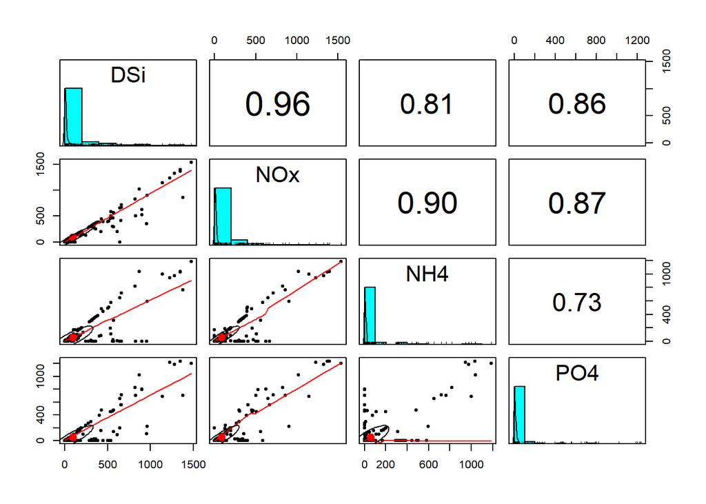

> also the lower left wedge area looks like a good target for things that are measured at the same time + place as DSi (and their ratios)

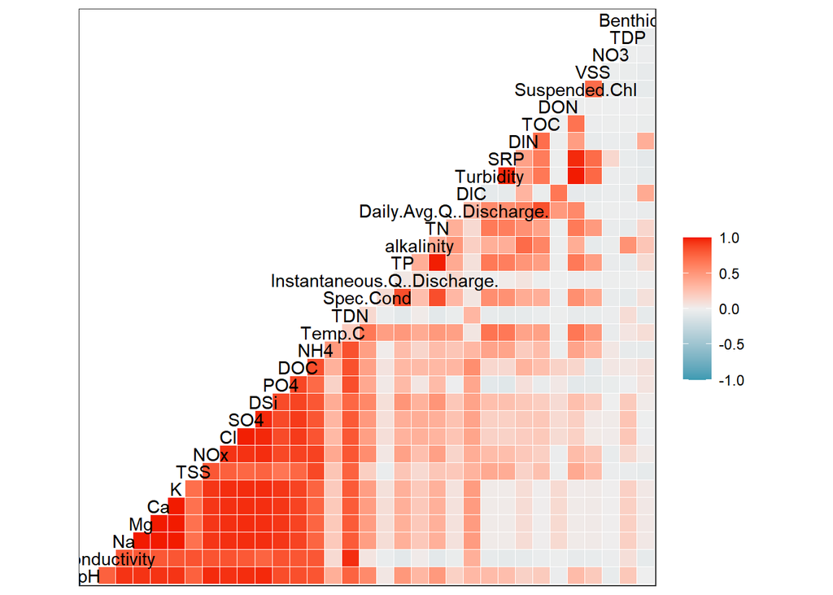

> correlations between DSi and other stuff

```
##           DSi           NOx           SO4           DOC           NH4
##     1.0000000     0.9592715     0.9690907     0.8892767     0.8136175
##           PO4           TSS            TN            TP           TDN
##     0.8612567     0.7610828     0.5039593     0.5078528     0.7419426
##           SRP Suspended.Chl           DIN           VSS
##     0.2648927     0.2731686     0.2217547     0.1962117
```

## PCA: clustering of analytes by site

```
## Importance of components:
##                             PC1       PC2       PC3       PC4       PC5
## Standard deviation     765.1675 264.05107 195.29139 123.84950 111.35787
## Proportion of Variance   0.7821   0.09314   0.05095   0.02049   0.01657
## Cumulative Proportion    0.7821   0.87524   0.92619   0.94668   0.96324
##                             PC6      PC7      PC8      PC9     PC10     PC11
## Standard deviation     93.08915 67.87064 64.35372 53.52508 43.91093 38.84660
## Proportion of Variance  0.01158  0.00615  0.00553  0.00383  0.00258  0.00202
## Cumulative Proportion   0.97482  0.98097  0.98650  0.99033  0.99291  0.99492
##                           PC12     PC13     PC14    PC15     PC16     PC17
## Standard deviation     34.6018 24.89503 21.87490 21.2398 15.70277 13.11238
## Proportion of Variance  0.0016  0.00083  0.00064  0.0006  0.00033  0.00023
## Cumulative Proportion   0.9965  0.99735  0.99799  0.9986  0.99892  0.99915
##                            PC18     PC19     PC20   PC21    PC22    PC23
## Standard deviation     11.96546 11.06147 10.45919 8.6849 7.29240 6.48589
## Proportion of Variance  0.00019  0.00016  0.00015 0.0001 0.00007 0.00006
## Cumulative Proportion   0.99934  0.99951  0.99965 0.9998 0.99982 0.99988
##                           PC24    PC25    PC26    PC27    PC28 PC29  PC30  PC31
## Standard deviation     5.96923 4.50965 3.30919 3.13069 2.27264 1.86 1.376 1.262
## Proportion of Variance 0.00005 0.00003 0.00001 0.00001 0.00001 0.00 0.000 0.000
## Cumulative Proportion  0.99993 0.99995 0.99997 0.99998 0.99999 1.00 1.000 1.000
##                          PC32   PC33
## Standard deviation     0.8901 0.4527
## Proportion of Variance 0.0000 0.0000
## Cumulative Proportion  1.0000 1.0000
```

> looks like maybe 2 distinct clusters - those with lots DSi, NOx, NO4, SO4, PO4 etc and then a couple with lots of TN, TP, chl, etc

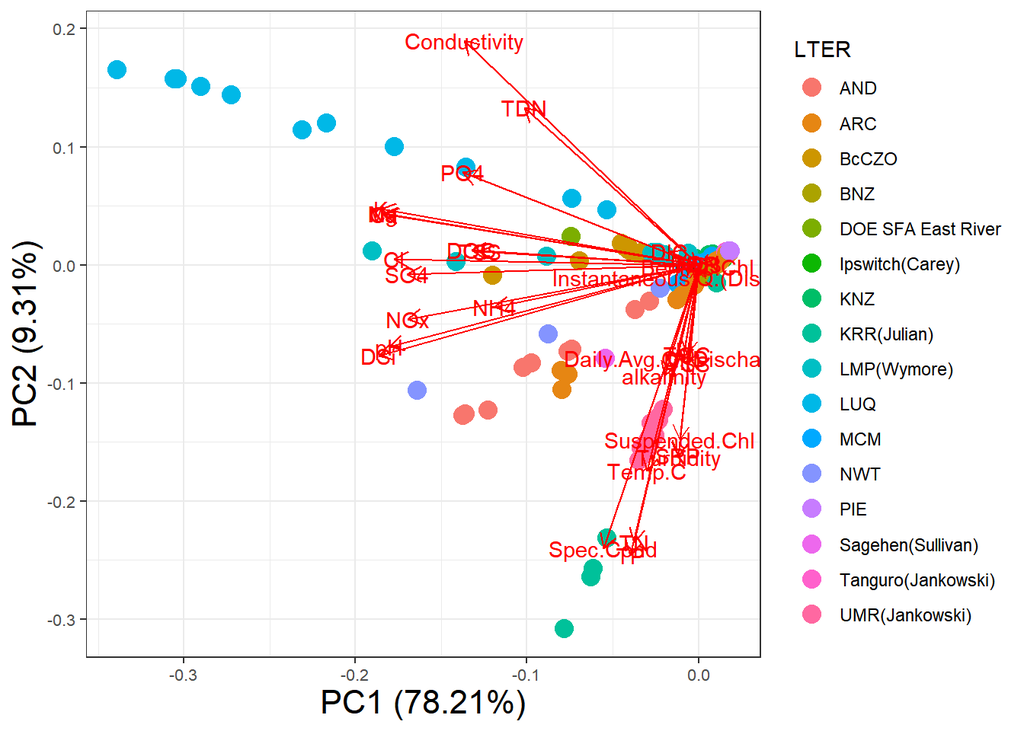

> or maybe 3 clusters - those with few data points (probably not super long term sites), then those with lots of data points but going either in the direction of TN/TP or NOx/PO4?

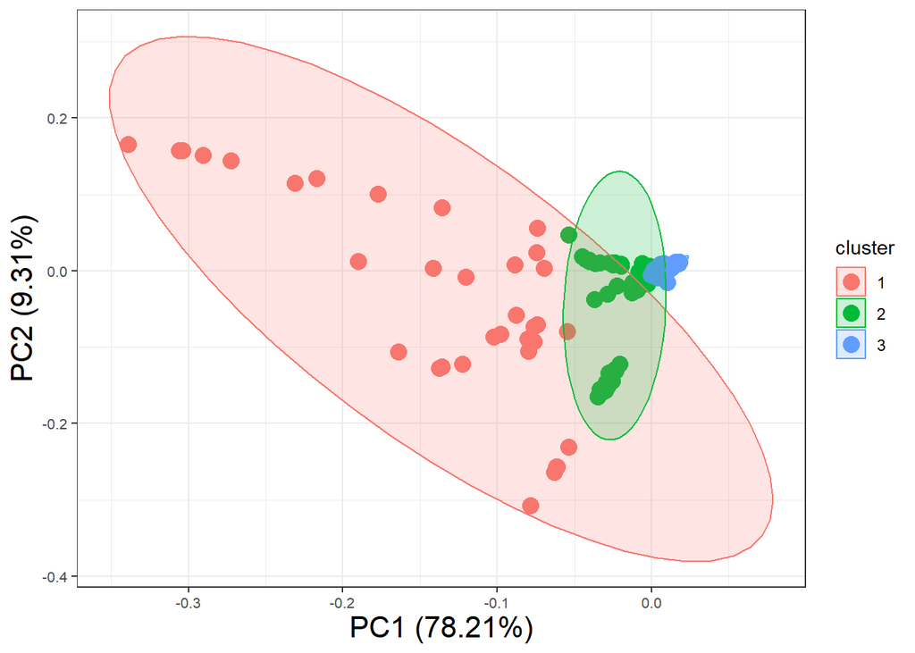

# Only long term sites

> filtering to get just the LTERs we will mostly focus on with long-term data (I think)

```r
# I think these are the right long term LTERS????
longtermLTERs <- c("ARC", "AND", "KRR(Julian)", "LMP(Wymore)", "LUQ", "MCM", "NWT", "Sagehen(Sullivan)", "UMR(Jankowski)")

thematrix2 <-  thematrix %>%
  filter(LTER %in% longtermLTERs)
```

> looks same as with all sites, at least that lower left wedge

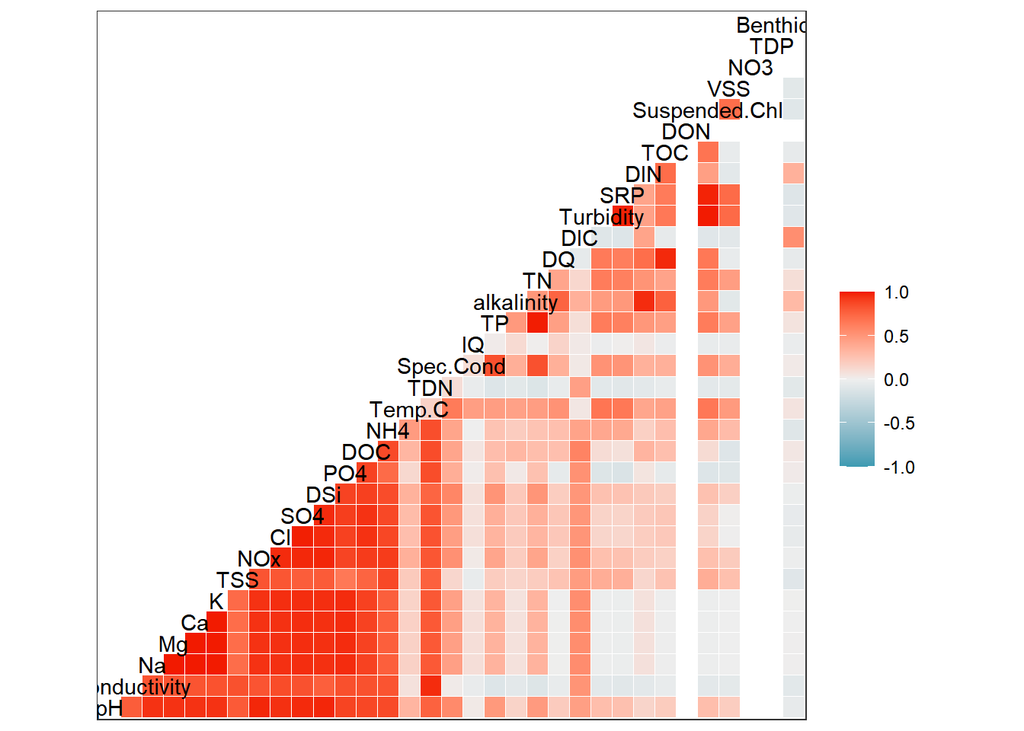

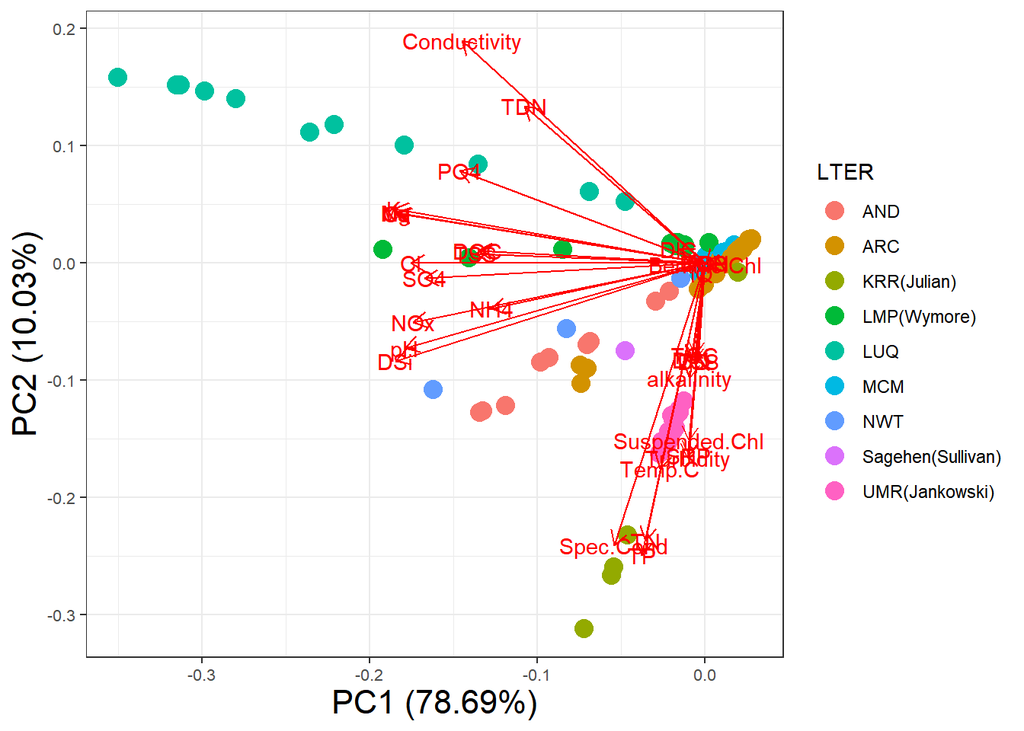

[figure not shown]

> another way to look at which of the long-term sites have what

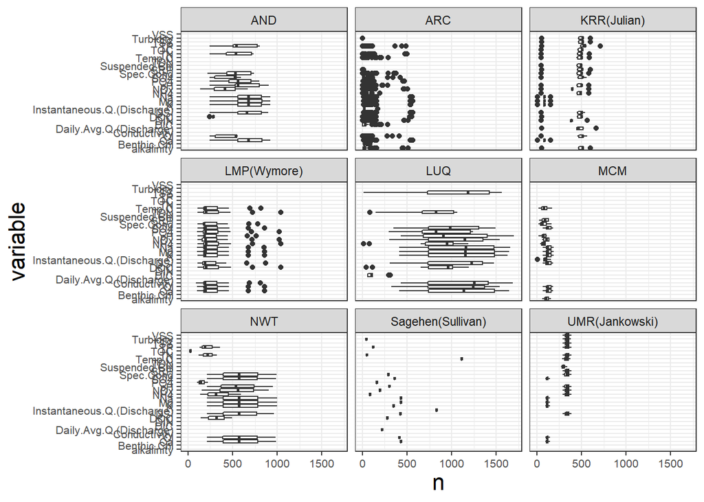

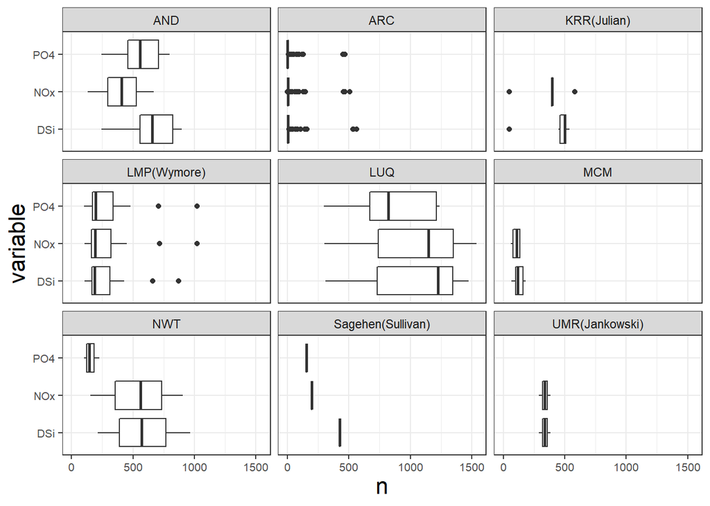

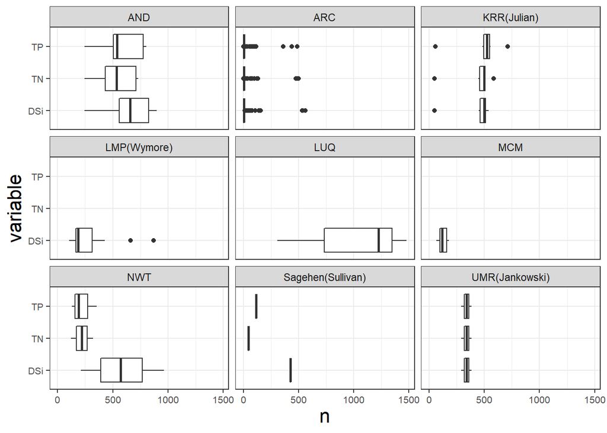